# Building on your foundations: going further with R

## What to expect

In this section we are going to:

- explore more advanced methods of handling and manipulating data
- learn how to plot data using `ggplot2`
- introduce the benefits of writing R scripts
- learn some basic R programming techniques

## Introduction

In the last chapter, we got to grips with the basics of R. Hopefully after completing the basic introduction, you feel more comfortable with the key concepts of R. Don’t worry if you feel like you haven’t understood everything - this is common and perfectly normal! Learning R is very much like learning a real language in that it takes time and practice to feel ‘fluent’. Even if you do feel comfortable in the language, there is no shame in asking for help or looking for more information to develop your understanding. As regular R users, we still look things up constantly and there are one or two basics which we still forget, even with over a decade of experience of using the R environemnt! With this in mind, a goal of these R tutorials is to re-emphasise and reinforce basic concepts throughtout. We will introduce concepts but through the practical demonstrations of code, we will underline them again and again.

In future chapters, we will be using a similar approach to reinforce the evolutionary genetic concepts you have encountered in the book. However, for this chapter we remain solely in the R environment and will instead switch our focus to more advanced features of R. Advanced does not necessarily mean more complicated - but it does mean that you need to have at least been introduced to the basic concepts. We will first ‘level-up’ our approach to handling and manipulating data. For this, we will be borrowing heavily from the [tidyverse](https://www.tidyverse.org) - a collection of packages and principles for data science in R. We will also introduce you to more advanced plotting, comparing the two most popular apporaches for plots - `base` and `ggplot`.

We will also use this chapter to introduce some important features of programming. We start with the benefits of using an R script to keep track of your code and to reproduce your analysis. We will then turn to introducing some basic programming techniques and operations in R. We will also show you how to write your own custom functions. For those with no prior familiarity with programming, these initial ventures into writing functions and operations might seem a little daunting, but again, we aim to re-emphasise them as much as possible.

## More advanced manipulating and handling data

Data manipulation might seem quite a boring topic but it is actually a crucial part of data science and increasingly, bioinformatics and evolutionary biology. For the average researcher working with biological data, we would estimate that the vast majority of analysis time is spent handling the data. By handling and manipulation, we mean exploring the data, shaping it into a form we want to work with and extracting information we find important or interesting. Getting to know your data is absolutely fundamental to properly understanding it and that is why we have decided to dedicate time to it in this chapter.

At this point in our tutorial, we will use a series of packages collectively known as the [tidyverse](https://www.tidyverse.org); in particularly, we will focus on functions from a tidyverse package calleed `dplyr`. These packages grew from the approach of [Hadley Wickham](http://hadley.nz/) - a statistician responsible for popularising fresh approaches to R and data science. As with nearly all things in R, there are many, many ways to achieve the same goal and the guidlines we give here are by no means definitive. However, we choose to introduce these principles now because in our experience of data analysis, they have greatly improved our efficiency, the clarity of our R code and the way we work with data.

Having used R for sometime, we have come to the tidyverse approach having already learned many of the basics in ‘normal’ or so-called ‘baseR’. It can be difficult to shake off what you have already learned! This is one of the reasons we are keen to introduce you to these approaches early on - they will be much easier for you to take on board if you are less familiar with the ‘standard’ way of doing things. A brief note on approaches - there is a surprising amount of snobbery and elitism for approaches to coding and scripting - this is true for R and other programming languages. We wish to steer well clear of this, the most important thing is learning how to use the tools at your disposal effectively and efficiently.

### Getting started with tidyverse packages

To go further, the very first thing we need to do is install and load the `tidyverse` package. Luckily, this is very straightforward! Run the following commands.

```r
install.packages("tidyverse")
library(tidyverse)
```

As mentioned before, we will focus mainly on the `dplyr` package here - occassionally we might use some other packages and if we do, it will be stated clearly. The next thing we need to do, is get some data to work with. We will use the `starwars` data from `dplyr` - you may be noticing a theme here…

```r
starwars <- dplyr::starwars
```

What did we do here? We assigned the `starwars` dataset - specifying it was frome `dplr` using the `::` - that basically means, ‘look inside `dplyr` for `starwars`’

If you take a look at the data by typing `starwars`, you will see it is stored as a `tibble`. This is a convenient way of displaying a `data.frame` and for all intents and purposes, behaves much the same way. It has the added advantage that it just shows you the first 10 lines of the data (known as the `head`). It also shows you what the data actually is - i.e. whether it is character data, integer, double or a factor. The tibble still behaves exactly as a it would as a standard `data.frame`. For example…

```r
starwars$name
```

…will produce a vector with the names of all the characters. Since the `tibble` only shows you the first 10 rows of your data, what if you want to see more? For that you can use the `print` function, like so:

```r
print(starwars, n = 15)
```

So now we have the package loaded and the data ready - we can start playing around with it!

### Selecting columns

Lets say we want to choose the name and homeworld columns from our `starwars` data, how can we do that? With standard R, we might do something like this.

```r
# with names
starwars[, c('name', 'homeworld')]
# with indices
starwars[, c(1, 9)]
```

With `dplyr` we can do the following:

```r
starwars %>% select(name, homeworld)
```

Wait a minute, what does `%>%` do!? This is a pipe - it essentially means, take the thing on the left and apply the function on the right to it. You can use it create chains of functions which you can easily apply to multiple data.frames if you need. It takes a bit of getting used to, but it can often clarify code. For consitency with standard R, we could have also written the code above like so:

```r
select(starwars, name, homeworld)
```

Both ways work and ultimately that is all that matters but for clarity and good practice, we will use the `%>%` pipe to make up our data handling workflows. So what else is going on with these two `tidyverse` inspired function calls? Well the function `select`, literally chooses columns from our `data.frame`. Hopefully the straightforwardness of this approach is a demonstration of how these packages can make R code more readable and easier to understand.

`select` is more powerful than just this. See some examples below:

```r
# choose all columns BUT name
starwars %>% select(-name)
# choose only columns containing an underscore
starwars %>% select(contains("_"))
# choose only columns beginning with "s"
starwars %>% select(starts_with("s"))
```

### Filtering data

We’ve seen now how to select columns using a `dplyr` approach - but what if we want to select rows? To do this, we need to filter the data on a given criteria. Let’s say we want to just select humans from our `starwars` data. We can achieve this using a logical approach - i.e. extracting only rows which match our criteria - i.e. whether the individual is human in this case. Let’s first see what happens when we apply a logical operation to the `species` column. Remember that for now, we will just use baseR.

```r
starwars$species == "Human"
```

All we did here is ask whether the species data is equal to the string ‘Human’. This returned a logical vector of `TRUE` and `FALSE` values. If we now use this to subset our `data.frame`, R will only return rows where the value is `TRUE`. For example:

```r
starwars[starwars$species == "Human", ]
```

Note that you have to specify you mean species within the `starwars` data using a `$` operator, because otherwise R doesn’t know where to look. In other words, the following will not work:

```r
starwars[species == "Human", ]
```

You should also note that we need a `==` instead of a `=` - this just means ‘is equal to’. So what is the `dplyr` alternative? We can use the straightforwardly names `filter` function for this:

```r
starwars %>% filter(species == "Human")
```

Notice we use the `%>%` pipe again - the reason for this will hopefully become clear soon! You might be wondering at this point, that there doesn’t seem to be a huge difference between these two approaches, other than the way the code looks. Where the `filter` command really becomes useful is when you use it for multiple different variables.

Let’s suppose we want to extract all individuals that are Human and that are from Tatooine as their homeworld. With baseR, we would do the following:

```r
starwars[starwars$species == "Human" & starwars$homeworld == "Tatooine", ]
```

What about with `dplyr`? Well this would work:

```r
starwars %>% filter(species == "Human", homeworld == "Tatooine")
```

You can see how `dplyr` makes filtering on multiple variables much more straightforward and cleaner.

### Filtering AND selecting data

What if you want to do multiple things to a dataset at once? Perhaps you need to get your data into a certain format or just want to subset it to only the variables you are interested in. As you get more and more experienced with R, you will find this is something you want to do regularly. It makes sense to manage your data, stripping it down to the key values of interest. This is part of the principle of [tidy data](http://garrettgman.github.io/tidying/).

Let’s return to our `starwars` dataset - what if we want to get the name, height and year of birth for all human species? If we use baseR, we would do it this way:

```r
starwars[starwars$species == "Human", c("name", "height", "birth_year")]
```

This sort of data manipulation requires us to first filter on the rows using `starwars$species == "Human"`. Remember back to Chapter 1, when we used square brackets to extract data from a matrix and then a data.frame? This is exactly the same thing.

Next, we select the columns we want in the second part of the brackets using `c("name", "height", "birth_year")`. This is fairly straightforward, even using baseR but you can imagine how this could be complicated if we wanted to select many different columns or filter on different variables.

What is the `dplyr` solution?

```r
starwars %>% filter(species == "Human") %>% select(name, height, birth_year)
```

Here we just pipe the data to `filter` and then again to `select`. It is worth noting here that the `tidyverse` solution might not be particularly faster or even much less code. It is (in our opinion at least) easier to read and to disentangle, if you come back to the code at a later date. There really is no right or wrong way to manipulate data in R - whichever approach you use is ultimately a matter of taste. However as you will see in the next section, `dplyr` approaches can really level up your ability to manipulate data.

### Summarising data

Where `dplyr` really excels is when you want to extract some kind of summary information from your data. Let’s start with a very straightforward example using our `starwars` data. What if we want to count the number of different species there are in the data? First, let’s actually look at the species present.

```r
starwars$species
```

You can see there are few different ones, although even from this it is fairly obvious humans are going to be the most numerous. If we want to count how many species there are, all we need to do is count the occurrence of each of these. Before we look at the `dplyr` solution, we will take a look at one more baseR way to achieve this.

```r
table(starwars$species)
```

This works and is fast but the main disadvantage is that our output is no longer a `data.frame`. It is also much more difficult to scale this approach up if we wish to group our dataset by multiple variables. But first, the `dplyr` equivalent of above is also straightforward:

```r
starwars %>% group_by(species) %>% tally()
```

All we have done here is first grouped our dataset by species using `group_by` and then counted the number of rows in each group using `tally`.

`group_by` can really come into its own when you want to count or tally data based on several variables. Let’s say we want to count the number of each gender of within each species. We would do it like so.

```r
starwars %>% group_by(species, gender) %>% tally()
```

We can do a lot more than just count occurrences with this functionality from `dplyr`. Perhaps we want to know the average height and mass of each species?

```r
starwars %>% group_by(species) %>% summarise(mean_height = mean(height, na.rm = T),
                                             mean_mass = mean(mass, na.rm = T))
```

Here all we did was use the `summarise` function to calculate mean height and mass. Since we used the `mean` function on both variables, we can actually simplify this even further like so:

```r
starwars %>% group_by(species) %>% summarise_at(vars(height, mass), mean, na.rm = T)
```

So this time we used `summarise_at` and specified the variables we wanted to summarise with the `vars` function.

Summarising data in this way is a useful skill, especially when you want to get a feel for what your dataset shows or you need to break it down into more understandable subsets. As we turn next to more advanced plotting using `ggplot2`, you will see that manipulating data is especially useful when you want create certain types of plots.

## Plotting with ggplot2

In the last chapter, we learned that R is highly versatile when it comes to plotting and visualising data. Visualistation really cannot be understated - as datasets become larger and more difficult to handle, it is imperative you learn how to effectively plot and explore your data. This obviously takes practice, but plotting and summarising data visually is a key skill for guiding further analysis - this is especially true for evolutionary genomics but is easily applicable to any number of scientific fields.

As you may have gathered by now, there are lots of opinions on how to use R - whether you should use base or tidyverse approaches. We want to stress that there is nothing wrong with using base plotting, it is capable of some very impressive plots (use `demo(graphics)` to have a look). However `ggplot2` is extremely flexible and takes quite a different approach to plotting compared to baseR.

### ggplot2 basics

The best way to get to grips with ggplot2 is just to use it, but before we delve in, there is one important point we should take note of. Unlike base R which can plot vectors directly, `ggplot2` requires that you provide it with some data first, usually in the form of a data.frame or tibble - like we dealt with in the previous section. Continuing with our theme from before, let’s use the `starwars` dataset again.

```r
starwars <- dplyr::starwars
```

Let’s do a simple scatter plot of the height and mass of the 87 characters in this dataset.

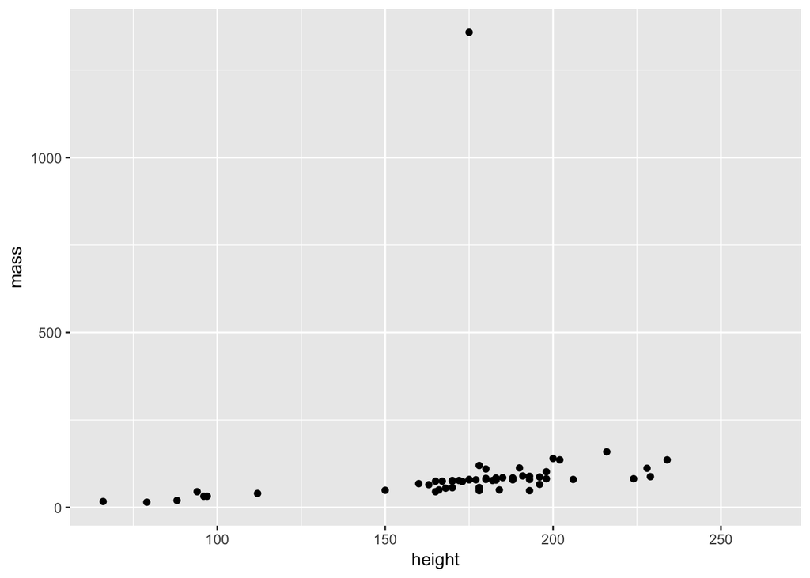

```r
ggplot(starwars, aes(height, mass)) + geom_point()
```

First take a moment to examine the plot - this is actually a brilliant example of why it is important to plot data since you can see that there is one individual with a **HUGE** mass that distorts our data visualisation. Is this is an error? Or perhaps someone with a ot of mass is in our dataset?

Before we investigate this, it is important to understand how our `ggplot2` command is built up:

- `ggplot()` is the function call to `ggplot2` - we provide this with two arguments, firstly we specify our dataset and then next we set an **aesthetic**
- the aesthetic in this case `aes(height, mass)`is just what variables to map to the **x** and **y** axes - height and mass here - note that this means you just need to provide the variable names - i.e. you don’t need to type `starwars$height`
- finally we specify a layer for the visualisation itself - in this case we want to plot the data as points on a scatter plot, so we use `geom_point()`
- note also that we used `+` to set up our ggplot function - this is because ggplot allows us to multiple layers of visualisation.

If you have used base graphics before, it can take some time to get used to the `ggplot2` way of doing things. However as we walk you through multiple examples here, you will soon get the hang of it and see that it is possible to easily customise plots.

But first, who has such a huge mass?

```
## # A tibble: 1 x 13
##   name     height  mass hair_color skin_color  eye_color birth_year gender
##   <chr>     <int> <dbl> <chr>      <chr>       <chr>          <dbl> <chr>
## 1 Jabba D…    175  1358 <NA>       green-tan,… orange           600 herma…
## # ... with 5 more variables: homeworld <chr>, species <chr>, films <list>,
## #   vehicles <list>, starships <list>
```

Well if you’ve seen Star Wars, the answer to this shouldn’t be a huge surprise… Let’s filter him out of the data

```r
starwars2 <- filter(starwars, name != "Jabba Desilijic Tiure")
```

Now we can replot the data and see what the relationship between height and mass is.

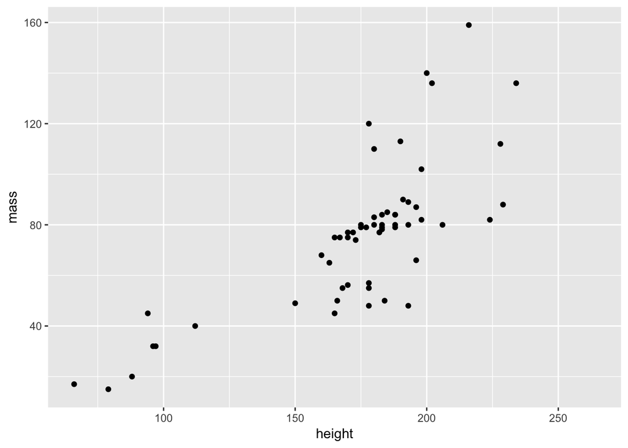

```r
ggplot(starwars2, aes(height, mass)) + geom_point()
```

As expected, mass generally increases with height!

### Customising a plot

How do we customise our scatter plot using `ggplot2`? Firstly, we can add some colour to the points.

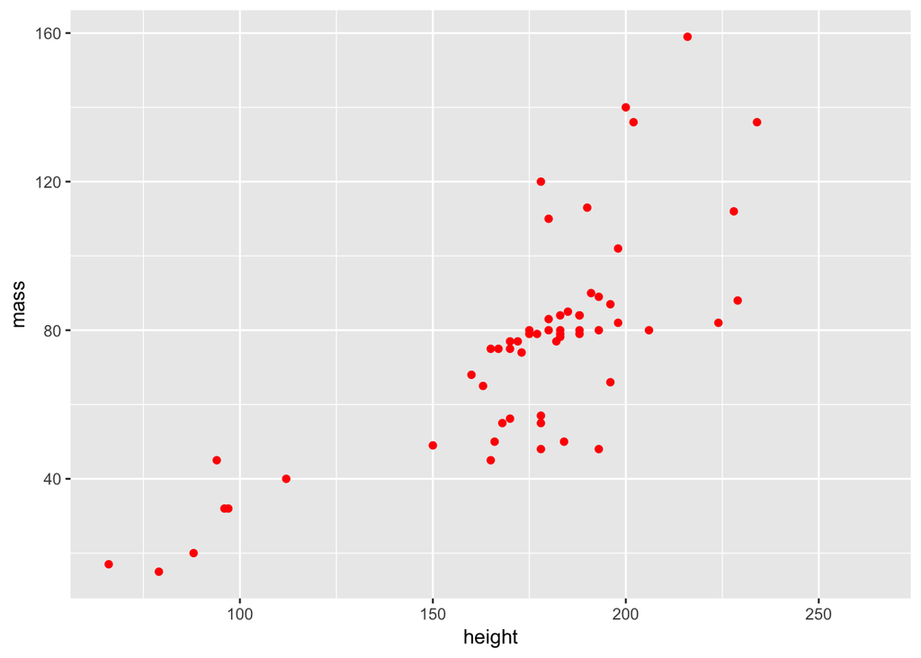

```r
ggplot(starwars2, aes(height, mass)) + geom_point(colour = "red")
```

Or we can change their colour and shape.

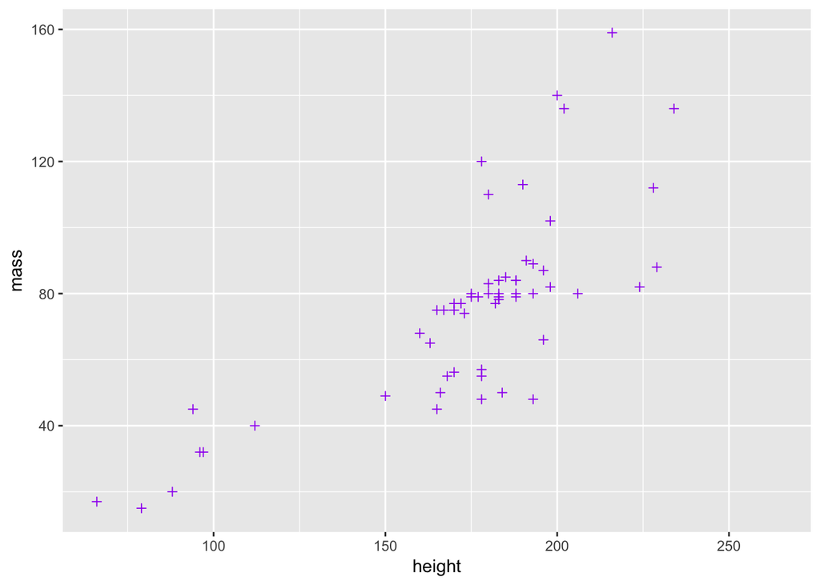

```r
ggplot(starwars2, aes(height, mass)) + geom_point(colour = "purple", pch = 3)
```

Note that in both of these cases, we added arguments to `geom_point` - the function that controls the plotting of the points. There is another way to change the point colour, involving the aesthetics, but we will deal with this in a moment.

Perhaps we want to alter the overall theme of the plot? We can do that by adding a theme.

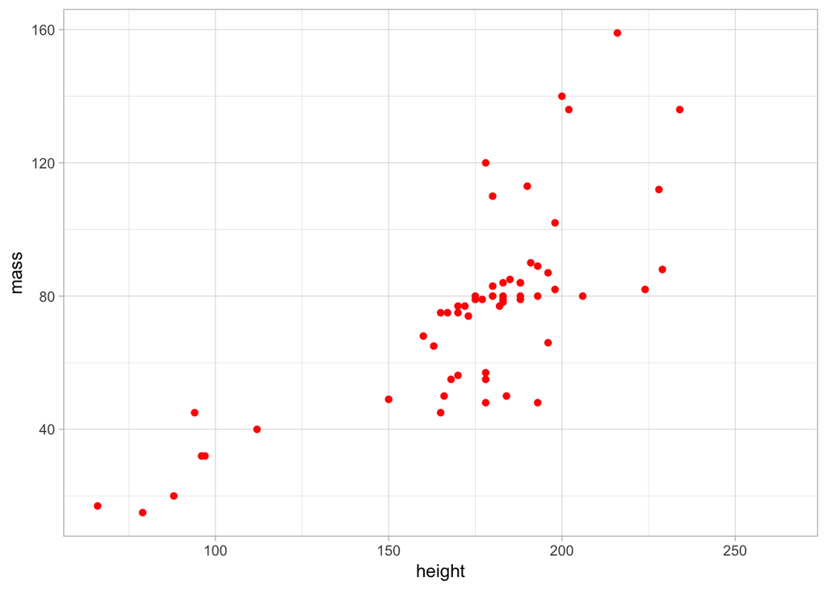

```r
ggplot(starwars2, aes(height, mass)) + geom_point(colour = "red") + theme_light()
```

By doing this, you can see again how we can build a plot by adding layers using `+`. It can get messy to do this all with one line, so a nice thing about `ggplot2` code is that you can assign it to objects and easily build a complex plot. For example:

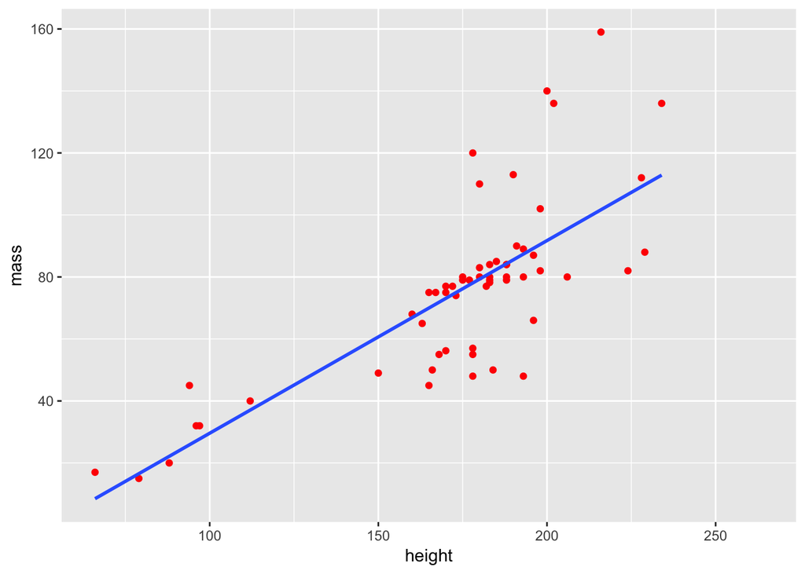

```r
a <- ggplot(starwars2, aes(height, mass))
a <- a + geom_point(colour = "red")
a + geom_smooth(method = lm, se = FALSE)
```

```r
a <- a + theme_light() + ggtitle("Height vs Mass in Star Wars")
```

What if instead of just colouring the points to make a plot look nice, we did it to actually try and learn something about the data? For example, we could colour the points by species. This however requires that we map point colour to species in the `aes` function of our command. We will return to the basic plot and do so below.

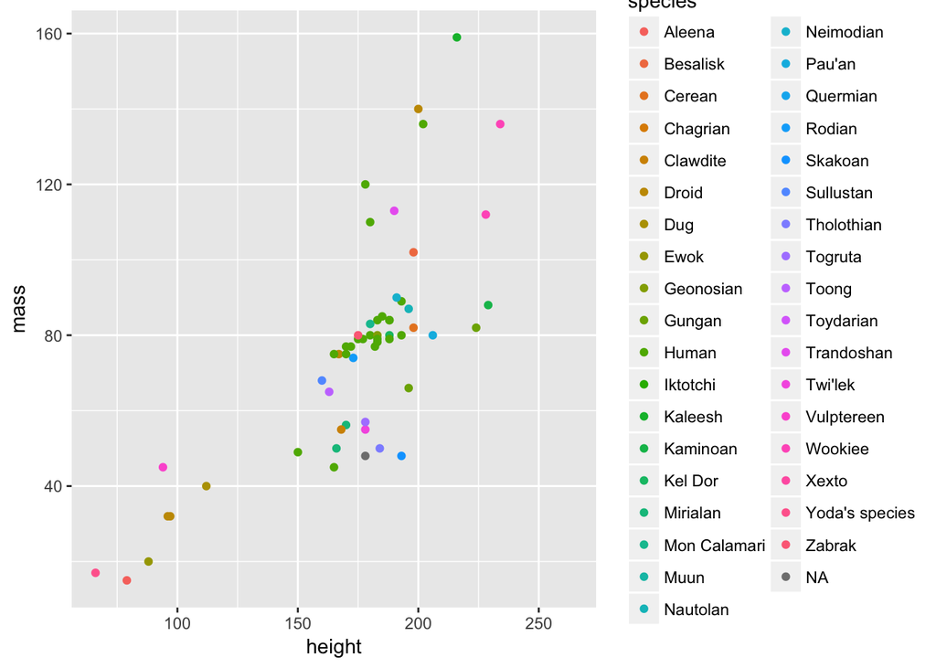

```r
ggplot(starwars2, aes(height, mass, colour = species)) + geom_point()
```

This is where the power of aesthetics starts to become apparent - with `ggplot2` it is very easy to map certain variables to an aesthetic and visualise them in a plot.

### Different types of plot with ggplot2

There are many different ways to visualise data using `ggplot2` beyond the standard scatter plot we have already seen. For a full list with reproducible examples, you should see the [ggplot2 manual](http://ggplot2.tidyverse.org/reference/). However, we will demonstrate a selection here and also get more of an idea of why `ggplot2` is so flexible.

#### Visualising data distributions

First of all, what if we want to look at the distribution of our data? For exampe, we could have looked at the distribution of mass in our dataset and spotted that Jabba was an issue before making our scatter plot. One way to do this would have been to plot a histogram using the `geom_histogram` layer.

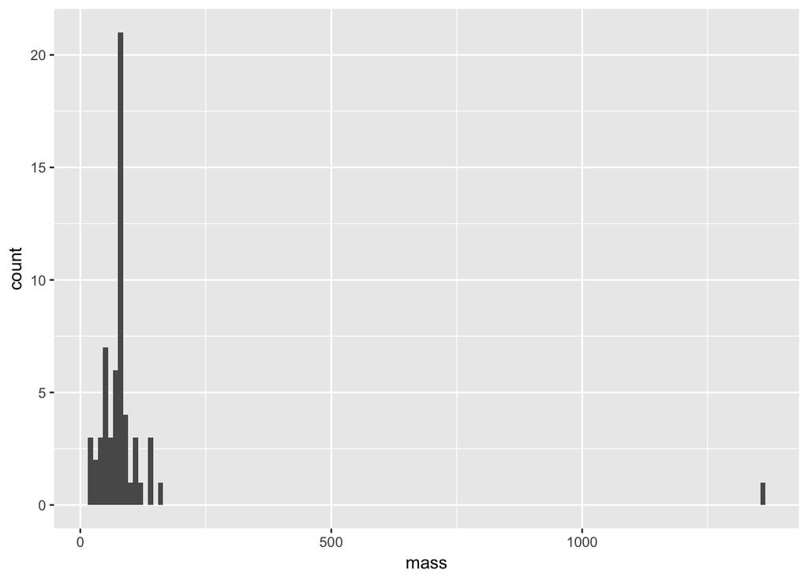

```r
a <- ggplot(starwars, aes(mass))
a + geom_histogram(binwidth = 10)
```

Note that within our `geom_histogram` layer function, we set the `binwidth` argument to **10**. In other words, we are binning our data by sets of 10. We could for example change this to **100** and see how the distribution changes.

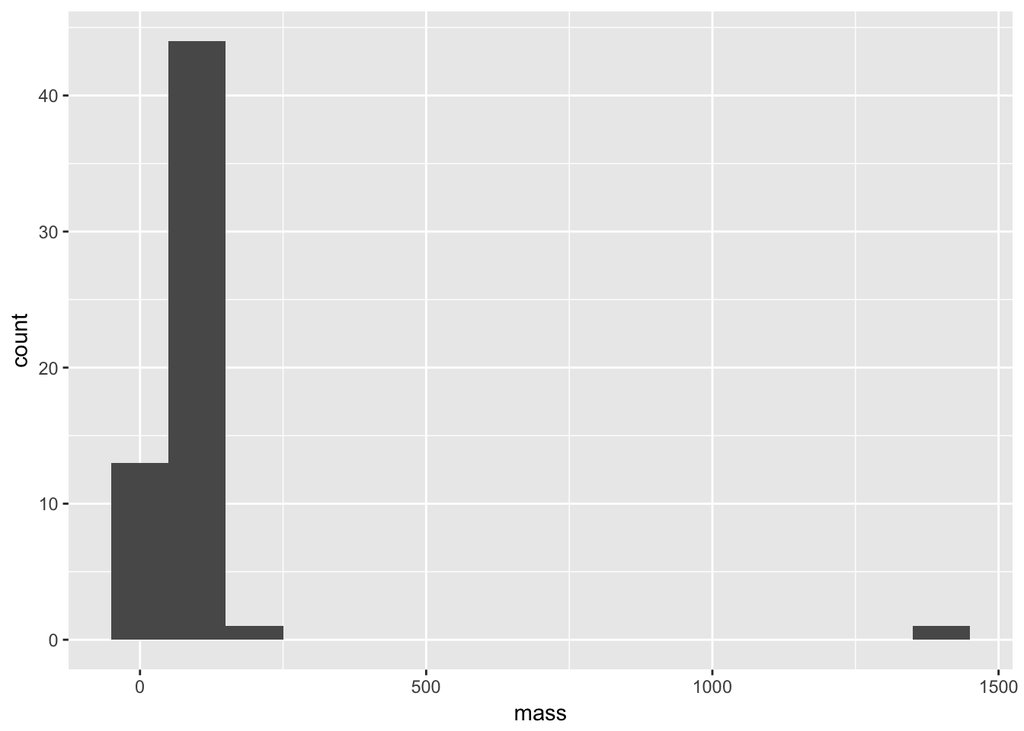

```r
a + geom_histogram(binwidth = 100)
```

Still though, Jabba is so huge he is an obvious outlier! We also see here that since we definied the basis of our plot as object `a` with the `ggplot` and `aes` functions, all we need to do to replot our histogram is alter the `geom_histogram` layer.

We can in fact completely change the type of plot. Another way to visualise a distribution is to use a smoothed density plot with the `geom_density` layer. All we need to do is change a small argument in our code.

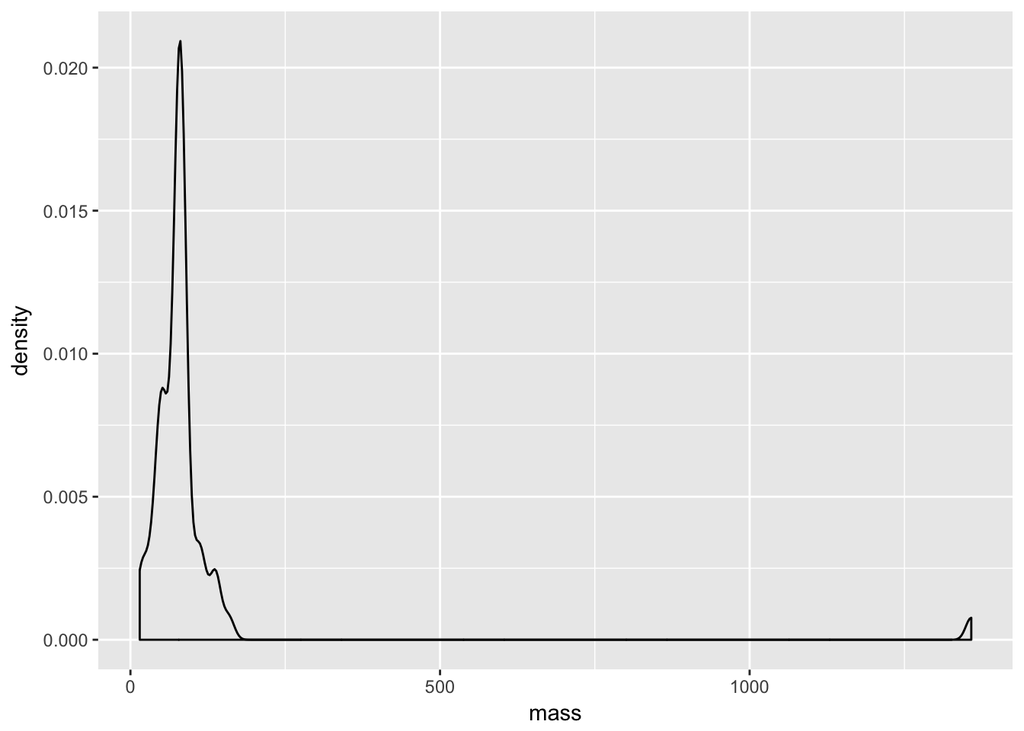

```r
a + geom_density()
```

#### Comparing data distributions

Perhaps we want to compare mass among the different species in our data? One way we can do this is with a boxplot like we did in Chapter 1. `ggplot2` makes this exceptionally easy with the `geom_boxplot` layer.

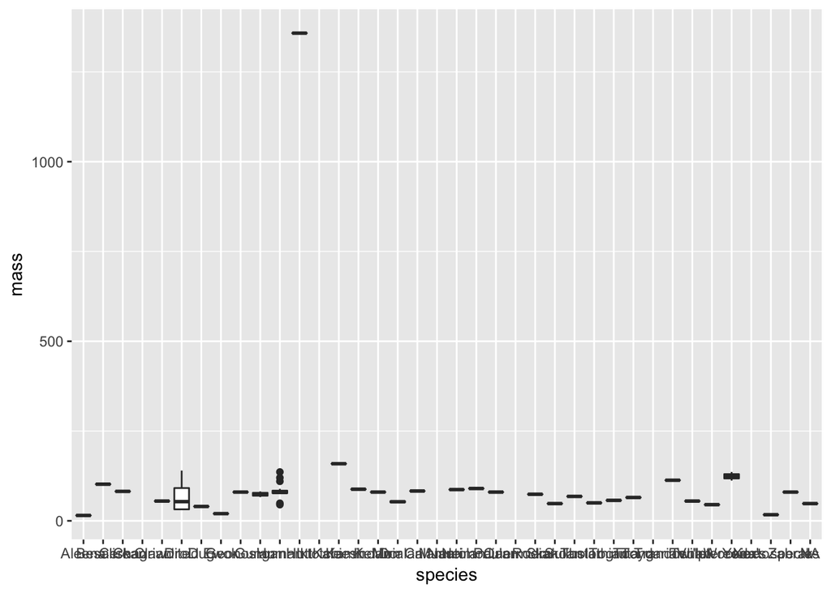

```r
a <- ggplot(starwars, aes(species, mass))
a + geom_boxplot()
```

Hmm - although this plot is detailed and we can still see there is a clear outlier, it is difficult to really see much more. This is an important point of data visualisation, you need to think what you hope those viewing the plot can learn from it.

Using the data handling skills we learned earlier in this session, let’s subset our data and visualise it again using `geom_boxplot`. To get started, we will compare the mass of humans, droids and ewoks.

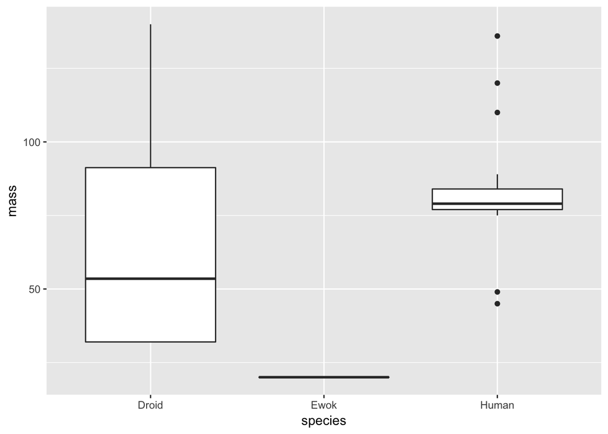

```r
# subset data
hde <- starwars %>% subset(species == "Human" | species == "Droid" | species == "Ewok")
# plot the distributions
a <- ggplot(hde, aes(species, mass))
a + geom_boxplot()
```

Clearly, Ewoks have a much lower mass than either droids or humans - but note here that there is only a single Ewok observation, so we can’t really compare the distribution of masses among these species.

We can however verify the number of observations for each species. We can do this using `dplyr` like so:

```
## # A tibble: 3 x 2
##   species     n
##   <chr>   <int>
## 1 Droid       5
## 2 Ewok        1
## 3 Human      35
```

We could also visualise this as a barplot with `ggplot2`. For example:

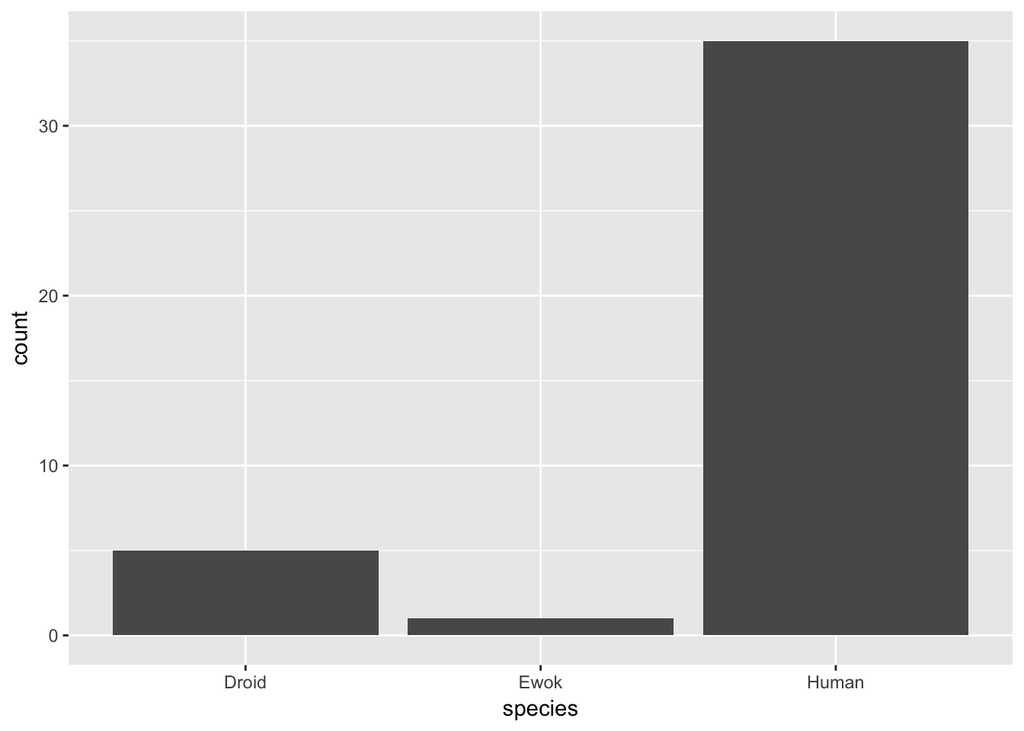

```r
ggplot(hde, aes(species)) + geom_bar()
```

#### More complicated plots and data handling

In some cases, we might want to visualise multiple variables clearly from a dataset. As an example, perhaps we want to look at the difference in both mass and height between humans and droids in a single plot.

Before we do this, let’s subset our data to just include humans and droids - since we know there is only a single Ewok in the data, we can drop it.

```r
hd <- starwars %>% subset(species == "Human" | species == "Droid")
```

What we would like to do is create a plot with two panels - one for boxplots showing height and the other for boxplots showing mass. We can achieve this with a layer known as `facet_grid` - however it requires our data to be in a slightly different format - we need to merge both our height and mass measurements into a single column. To do this, we will use a function called `gather`.

```r
# first we select only the variables we are interested in
hd <- hd %>% select(name, height, mass, species)
hd_g <- hd %>% gather(key = "measurement", value = "value", -name, -species)
hd_g
```

```
## # A tibble: 80 x 4
##    name               species measurement value
##    <chr>              <chr>   <chr>       <dbl>
##  1 Luke Skywalker     Human   height        172
##  2 C-3PO              Droid   height        167
##  3 R2-D2              Droid   height         96
##  4 Darth Vader        Human   height        202
##  5 Leia Organa        Human   height        150
##  6 Owen Lars          Human   height        178
##  7 Beru Whitesun lars Human   height        165
##  8 R5-D4              Droid   height         97
##  9 Biggs Darklighter  Human   height        183
## 10 Obi-Wan Kenobi     Human   height        182
## # ... with 70 more rows
```

What happened here? Within `gather` we specified our `key` variable to be **measurement** - this just creates a character vector with two values, height and mass. We also give our combined variable a name - **value** here. So now, we have a tibble with twice as many rows as the original but with one for height and one for mass.

We can demonstrate this by actually looking for a single name and seeing there are two rows - one for height and one for mass. For example

```r
filter(hd_g, name == "R2-D2")
```

```
## # A tibble: 2 x 4
##   name  species measurement value
##   <chr> <chr>   <chr>       <dbl>
## 1 R2-D2 Droid   height         96
## 2 R2-D2 Droid   mass           32
```

Use of `gather` in this way is a bit counterintuitive at first, but with practice you will see it becomes much more straightforward.

So what was the point of this anyway? Well it allows us to construct our plot like this:

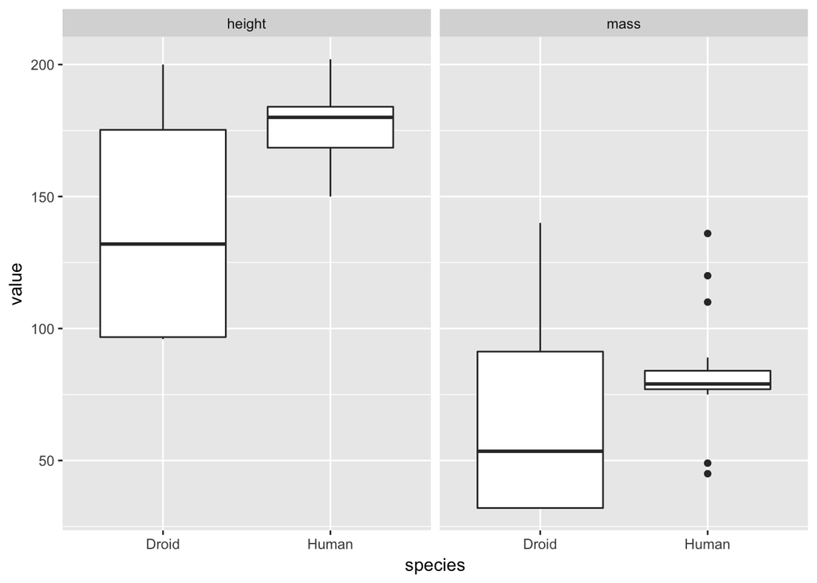

```r
a <-  ggplot(hd_g, aes(species, value)) + geom_boxplot()
a + facet_grid(~measurement)
```

As normal, we specified the data and aesthetics for our plot. However we added the `facet_grid` argument to split the plot into facets over the different types of measurement (i.e. height and mass here). The `~measurement` part of this command just means we should fill the facet grid as new columns. We could also use `measurment~.` to do the same by rows (note that the `.` is necessary to allow R to interpret the command properly). Like so:

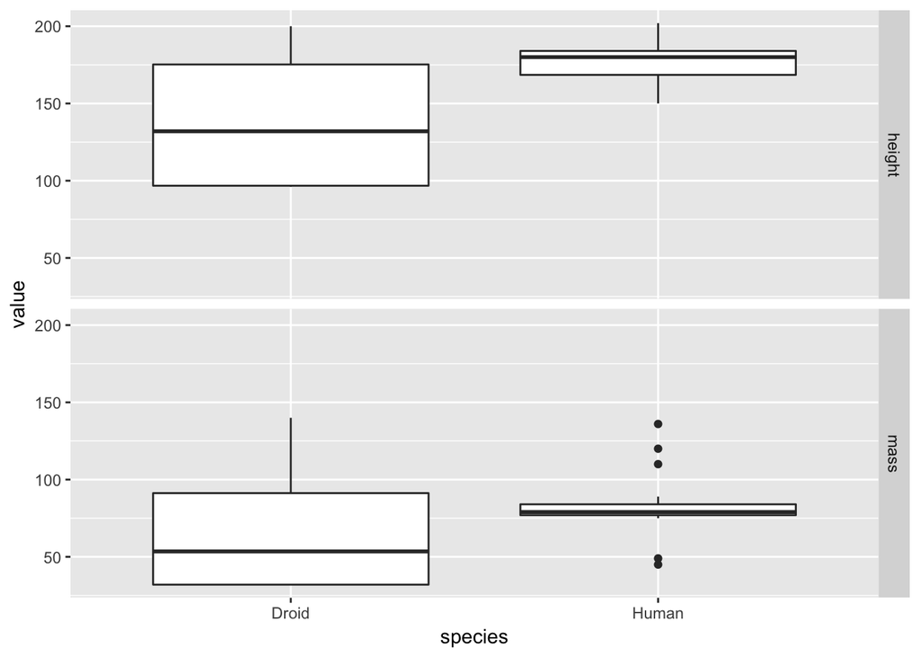

```r
a + facet_grid(measurement~.)
```

It is a matter of opinion, but the we think that the first plot looks better! Either way, from both plots it is clear that the humans are on average taller than droids but that there is much greater variation in both droid mass and height!

### Annotating and making publication quality plots

The concept of layers in `ggplot2` is similar in ethos to that used in graphic design programs such as Adobe Illustrator or Photoshop. You create a plot and you can add layers of detail to it. This makes it very straightforward to create a publication quality figure with a few lines of code.

Let’s return to our earlier density plot of mass from our `starwars` data.

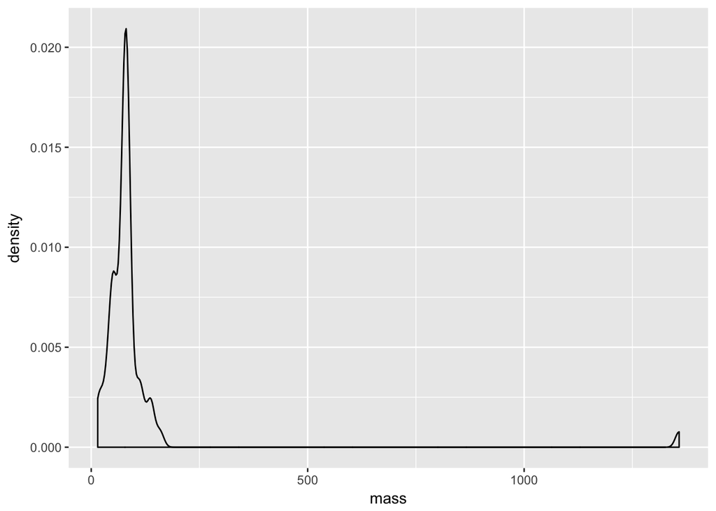

```r
a <- ggplot(starwars, aes(mass))
a <- a + geom_density(binwidth = 10)
a
```

With the code above, we have commpletely assigned our plot to the object `a`. So now all we need to do is add layers to it to annotate it.

First of all, let’s plot mean value of mass as a vertical line on the plot. To do this we need to calculate the mean, which we would do like so:

```r
mean_mass <- mean(starwars$mass, na.rm = T)
mean_mass
```

We need the `na.rm = T` argument here because some individuals do not have a measured mass (i.e. they are `NA`) - without this, a call to the `mean` will only produce an `NA`. Anyway, now that we have defined our mean mass, we can add it to our plot as a line like so.

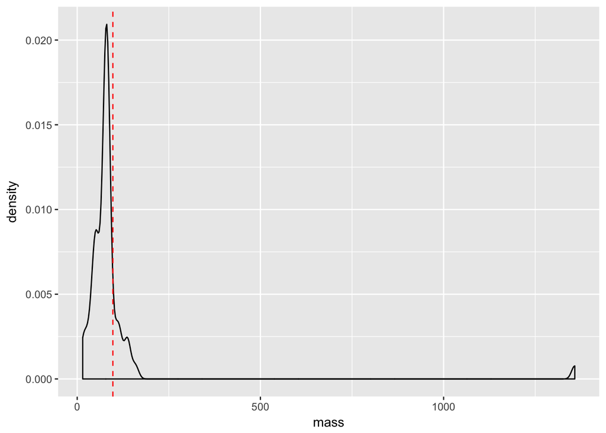

```r
a <- a + geom_vline(xintercept = mean_mass, lty = 2, colour = "red")
a
```

Next we can add some theme arguments to make our plot suitable for publication.

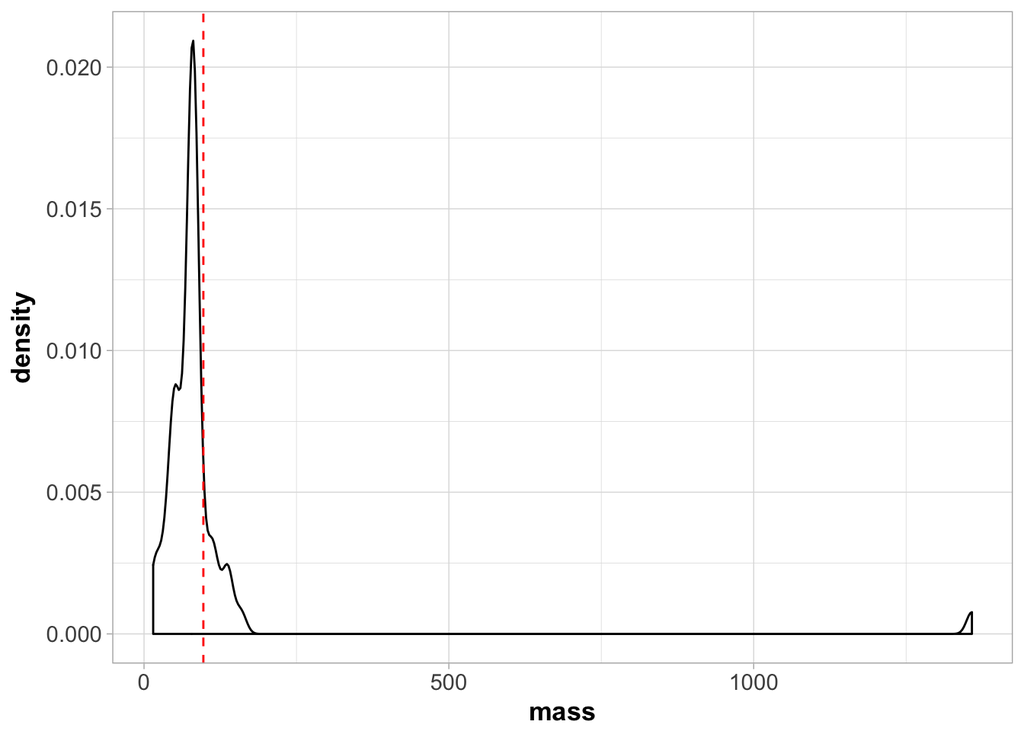

```r
a <- a + theme_light()
a <- a + theme(axis.title = element_text(size = 13, face = "bold"),
               axis.text = element_text(size = 11))
a
```

Note that here we have to call `theme_light()` first or it will override all the other arguments we made to `theme()` later.

There is a huge amount you can do to make plots look more aesthetically pleasing - you should check out all the options available in [the ggplot2 manual](http://ggplot2.tidyverse.org/index.html).

Finally, once you have created a plot you like, you might want to save it. You can do this easily using the `ggsave`.

```r
ggsave("./myplot.pdf", plot = last_plot(), device = "pdf")
```

Here we saved a plot to the current directory (use `getwd()` if you need to find out where this is) as pdf caled `myplot.pdf`.

### Some last words on ggplot2

Hopefully the last section has convinced you that `ggplot2` is a versatile and flexible tool for data visualisation. There are many more things that are possible with the package but unfortunately, we do not have the time or space to go into them all here. Nonetheless, `ggplot2` will be used throughout the remainder of our R sections, so when new topics or concepts arise, we will do our best to explain them.

However, if you are keen to learn more about `ggplot2`, we highly recommend the [R Graphics Cookbook](http://www.cookbook-r.com/Graphs/) as an entry level tutorial.